# Calculating Proportion Intersect using Simple Features (sf)

Ryan Gan

10/12/2017

## Introduction and setup

This is example code on using the relatively new “sf” simple features package. Perviously, I have used the sp, rgeos, and rgdal package for many spatial tasks/calculations. Use of sf allows for a faster and more memory-efficient way to perform spatial tasks. From what I can tell, the major difference is that a simple feature is more like a dataframe rather than a spatial polygon object. This would explain why it’s more memory efficient. Another very attractive feature is that “sf” follows tidy principles for data manipulation and managment, and is compatible with the tidyverse. For this, I use the development version of ggplot2 to access the geom_sf feature. I expect “sf” and tidyverse to work even better together in the future.

This document focuses on calculation of the intersection between two spatial polygons (shapefiles). The reason I want to calculation the intersection is so that I could population weight PM<sub>2.5</sub> values based on grid cells for a given politcal boundary, in this case, county. This is my first time taking the “sf” package for a go and I’m excited about it’s potential.

Let’s read in the shapefile polygons for the Bluesky smoke forecasting grid and the polygons for United States counties (excluding Alaska and Hawaii).

```r
# trying out sf for the first time
library(sf)
```

```r
# note that you need the development version of ggplot2
library(tidyverse)
# load wrfgrid polygon ----
# define relative path to polygon file
poly_path <- "../data/bluesky_grid"
poly_layer <- "bluesky_grid"
# county path
co_path <- "../data/us_county"
co_layer <- "us_county"

# read in bluesky grid
bluesky_grid <- st_read(dsn = poly_path, layer = poly_layer)
# the bluesky grid does not have an ID so we will assign each cell a number
bluesky_grid$id <- as.numeric(seq(1:94068))
# read county polygons
us_county <- st_read(dsn = co_path, layer = co_layer)
```

Now that we’ve read in the two polygons, it looks like there are some unique features to the sf package vs some other packages like rgdal or rgeos. It looks like the imported simple features object contains more information than the simple polygon, which is cool. I haven’t plotted the entire US and the Bluesky grid because it’s hard to see, but I usually do this as a check.

## Subsetting specific polygons

In the past, we calculated the proportion of intersection between each county polygon and grid cell for one state, which worked fine. However, when we try to apply the same method to the entire US, we ran in to what I think were memory problems (stack overflow?), and we were never able to get our desired product, a matrix of the proportion intersect for each cell id and county id. This was on a relatively decent high-performance computer too running in parallel and definately wouldn’t work on your standard desktop or laptop. To solve this problem, we’ll subset each state and only the cell grids of that state, which should reduce our memory use substantially. We can save the matrix for each state, free up the memory used, and start again with a new state. We can then combine all the matrices from each state to get our desired matrix.

For this example, we’ll take it to a much smaller scale: the state of California.

We’ll also check the plots of each object to make sure we have what we need.

```r
# subset to california by FIPS code "06"
cali_county <- us_county[us_county$STATEFP=="06", ] %>%
  # making a FIPS ID that I'll use later
  mutate(FIPS = paste0(STATEFP, COUNTYFP))
# subset the bluesky grid to  grid cells that intersect a california county
cali_grid <- bluesky_grid[cali_county, ]
```

```
## although coordinates are longitude/latitude, it is assumed that they are planar
```

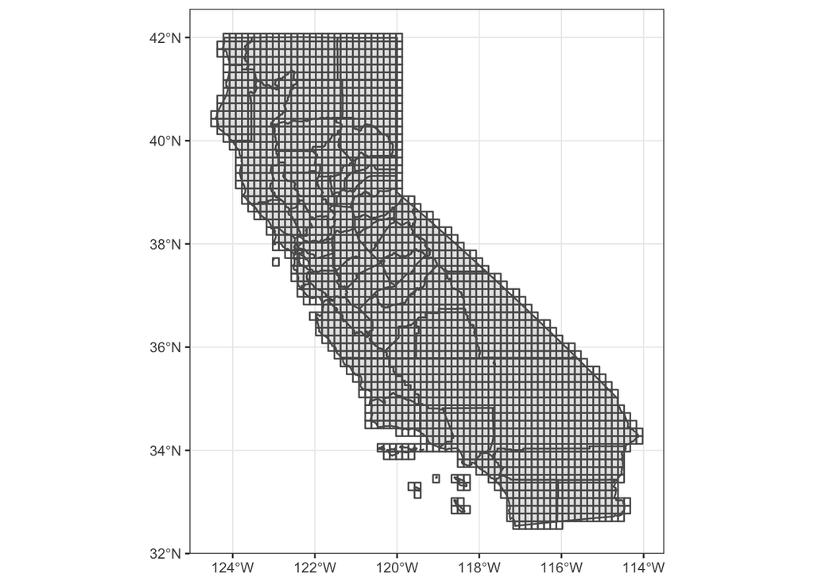

```r
# plot
ggplot(cali_county) +
  geom_sf() +
  geom_sf(data=cali_grid, aes(), alpha = 0.0) +
  theme_bw()
```

Looks like we have all the grids we need for the state of California. Let’s move on to the proportion of intersection between each county and grid in each state.

## Proportion intersect calcuations

Before we apply a function to the whole state, we’ll subset start small with one county and grids in that county. I do this for a couple reasons. The first is I can test if my code is working on a small subset on my laptop before moving it to the server. The second is that it is easy to scale it up and use *apply* functions to apply the formula for each grid and county (for the entire US, eventually). The last reason is that I’ll check the final matrix for the grid ids for that particular county to make sure they line up with these calculations here.

I’m going to pick Los Angeles county since it’s small and has some islands. We can subset in the same way we did before.

```r
# subset orange county by fips code
la_county <- cali_county[cali_county$COUNTYFP=="037",]
# subset grids to orange county
la_grid <- cali_grid[la_county, ]
```

```
## although coordinates are longitude/latitude, it is assumed that they are planar
```

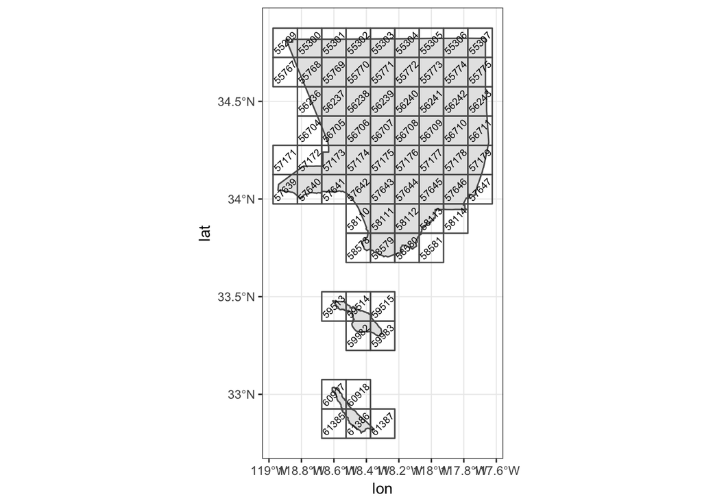

```r
# dataframe of name and centroid to plot
grid_names <- la_grid %>%
  group_by(id) %>%
  mutate(lon = unlist(st_centroid(geometry))[1],
         lat = unlist(st_centroid(geometry))[2]) %>%
  ungroup() %>%
  select(id, lon, lat)
# convert simple featrues to dataframe
st_geometry(grid_names) <- NULL

# plot grid over LA county and label grid cells
ggplot() +
  geom_sf(data = la_county) +
  geom_sf(data=la_grid, alpha = 0.0) +
  geom_text(data=grid_names, aes(x=lon, y=lat, label=id), size = 2.5, angle=45)+
  theme_bw()
```

We’ll calculate the proportion intersection of one grid, 55299, for the upper part of LA county.

```r
# first find the intersection between the two shapes
intersect_sf <- st_intersection(la_county, la_grid[1,])
# find the proportion intersect by subtracting the area of the intersection
# by the area of the grid cell. as.numeric ditches the unit
prop_intersect <- as.numeric(st_area(intersect_sf)/st_area(la_grid[1,]))
# proportion of LA county in the grid 55299, which is the upper left hand corner
prop_intersect
```

```
## [1] 0.1759436
```

Since “sf” brings in polygons as simple features as a data frame instead of multiple little polygons as part of a larger polygon, that changes how I can calculate proportion intersect. I believe it’s more intuitive, takes less memory, and much faster.

Calculating the proportion intersect between all grids in LA county with LA county is as simple as putting the whole grid in the intersect function. Before, I had to subset each grid and find each intersection with the county polygon, which took a lot longer.

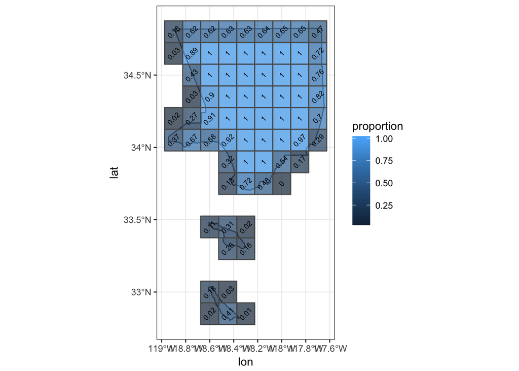

```r
# sf might make this easier since each object comes in as a dataframe and not
# a bunch of little polygons as part of a big polygon
# find intersection of grid for the county
grid_area <- st_intersection(st_geometry(la_grid),st_geometry(la_county))
# caluclate proportion intersect
prop_int <- as.numeric(st_area(grid_area)/st_area(la_grid))
# now I need to assign it back to the county shapefile
la_grid$proportion <- prop_int

# make a dataframe with rounded proportion values
grid_names <- la_grid %>%
  mutate(proportion = round(prop_int,2)) %>%
  group_by(id) %>%
  mutate(lon = unlist(st_centroid(geometry))[1],
         lat = unlist(st_centroid(geometry))[2]) %>%
  ungroup() %>%
  select(id, lon, lat, proportion)
# convert simple featrues to dataframe
st_geometry(grid_names) <- NULL

# plot
ggplot(la_county) +
  geom_sf() +
  geom_sf(data=la_grid, aes(fill=proportion), alpha=0.7) +
  geom_text(data=grid_names, aes(x=lon, y=lat, label=proportion),
            size = 2.5, angle=45) +
  theme_bw()
```

I calculated the intersection for each grid with the county shape, plotted a gradiet fill and the value of the proportion intersect. Based on the eye-ball test, it looks like our function worked. Our top-left grid cell also matches what we calculated before (I rounded to the nearest hundreth).

Try it out on the state of California. I don’t think I can use purrr map functions yet. I’ll use a for loop.

```r
# I had some problems feeding the sf object directly in to the function when I
# tried to use the apply or map functions, which led me to think purrr and map
# were not compatible yet. If I feed in a vector of the state/county fips,
# this should work

# tibble of just the grid_id to join data too
prop_int_tibble <- cali_grid$id %>%
  tibble() %>%
  rename(grid_id = ".")

# turning this in to a for loop because i'm annoyed
for(i in 1:length(cali_county$FIPS)){
  # subset county to find intersect
  county <- slice(cali_county, i)
  # extract fips number for variable name
  fips_id <- paste0("fips_", county$FIPS)
  # subset grid cells that touch any part of the county
  grid <- cali_grid[county,]
  # output grid IDs
  grid_id <- grid$id
  # subset the intersected polygon
  inter_poly <- st_intersection(st_geometry(grid),st_geometry(county))
  # find proportion intersect with original grid
  prop_int <- as.numeric(st_area(inter_poly)/st_area(grid))
  # make a tibble
  prop_int_tibble <- tibble(grid_id, prop_int) %>%
    set_names(c("grid_id", fips_id)) %>%
    right_join(prop_int_tibble, by = "grid_id")
} # end loop
```

[output not shown]

```r
# that was fast enough and easier to follow
summary(prop_int_tibble)
```

```
##     grid_id        fips_06031       fips_06073       fips_06101
##  Min.   :32800   Min.   :0.0906   Min.   :0.0060   Min.   :0.0021
##  1st Qu.:40768   1st Qu.:0.2850   1st Qu.:0.3484   1st Qu.:0.1474
##  Median :48731   Median :0.7987   Median :1.0000   Median :0.3792
##  Mean   :47765   Mean   :0.6411   Mean   :0.7064   Mean   :0.4287
##  3rd Qu.:54824   3rd Qu.:1.0000   3rd Qu.:1.0000   3rd Qu.:0.6291
##  Max.   :62338   Max.   :1.0000   Max.   :1.0000   Max.   :1.0000
##                  NA's   :2002     NA's   :1960     NA's   :2010
##    fips_06095       fips_06075       fips_06103       fips_06093
##  Min.   :0.0007   Min.   :0.0039   Min.   :0.0004   Min.   :0.0162
##  1st Qu.:0.3345   1st Qu.:0.0416   1st Qu.:0.1717   1st Qu.:0.5295
##  Median :0.6682   Median :0.0593   Median :0.7433   Median :1.0000
##  Mean   :0.5859   Mean   :0.1157   Mean   :0.6214   Mean   :0.7971
##  3rd Qu.:0.8621   3rd Qu.:0.1826   3rd Qu.:1.0000   3rd Qu.:1.0000
##  Max.   :1.0000   Max.   :0.2910   Max.   :1.0000   Max.   :1.0000
##  NA's   :2009     NA's   :2022     NA's   :1969     NA's   :1928
##    fips_06063       fips_06049       fips_06035       fips_06029
##  Min.   :0.0057   Min.   :0.0804   Min.   :0.0093   Min.   :0.0000
##  1st Qu.:0.2058   1st Qu.:0.4812   1st Qu.:0.1927   1st Qu.:0.3615
##  Median :0.7848   Median :1.0000   Median :1.0000   Median :1.0000
##  Mean   :0.6346   Mean   :0.7917   Mean   :0.6973   Mean   :0.7452
##  3rd Qu.:1.0000   3rd Qu.:1.0000   3rd Qu.:1.0000   3rd Qu.:1.0000
##  Max.   :1.0000   Max.   :1.0000   Max.   :1.0000   Max.   :1.0000
##  NA's   :1977     NA's   :1961     NA's   :1944     NA's   :1902
##    fips_06021       fips_06109       fips_06067       fips_06105
##  Min.   :0.0573   Min.   :0.0097   Min.   :0.0001   Min.   :0.0007
##  1st Qu.:0.6370   1st Qu.:0.3443   1st Qu.:0.1623   1st Qu.:0.4503
##  Median :0.8283   Median :0.7063   Median :0.4607   Median :0.8551
##  Mean   :0.6961   Mean   :0.6248   Mean   :0.4922   Mean   :0.6778
##  3rd Qu.:0.9375   3rd Qu.:0.9990   3rd Qu.:0.7732   3rd Qu.:1.0000
##  Max.   :1.0000   Max.   :1.0000   Max.   :1.0000   Max.   :1.0000
##  NA's   :2004     NA's   :1984     NA's   :2003     NA's   :1969
##    fips_06077       fips_06047       fips_06065       fips_06079
##  Min.   :0.0018   Min.   :0.0001   Min.   :0.0013   Min.   :0.0020
##  1st Qu.:0.2645   1st Qu.:0.2105   1st Qu.:0.6205   1st Qu.:0.1302
##  Median :0.6612   Median :0.6925   Median :1.0000   Median :0.7816
##  Mean   :0.6011   Mean   :0.6083   Mean   :0.7573   Mean   :0.6222
##  3rd Qu.:1.0000   3rd Qu.:1.0000   3rd Qu.:1.0000   3rd Qu.:1.0000
##  Max.   :1.0000   Max.   :1.0000   Max.   :1.0000   Max.   :1.0000
##  NA's   :1999     NA's   :1989     NA's   :1919     NA's   :1966
```

[output cut: 65 more lines]

```
##  Min.   :0.0026   Min.   :0.0001   Min.   :0.0000   Min.   :0.0001
##  1st Qu.:0.1125   1st Qu.:0.4414   1st Qu.:0.2826   1st Qu.:0.3305
##  Median :0.4992   Median :0.9553   Median :0.9152   Median :0.6817
##  Mean   :0.5494   Mean   :0.7260   Mean   :0.6779   Mean   :0.6460
##  3rd Qu.:0.9652   3rd Qu.:1.0000   3rd Qu.:1.0000   3rd Qu.:1.0000
##  Max.   :1.0000   Max.   :1.0000   Max.   :1.0000   Max.   :1.0000
##  NA's   :1998     NA's   :1966     NA's   :1924     NA's   :1994
##    fips_06011       fips_06009       fips_06007
##  Min.   :0.0004   Min.   :0.0010   Min.   :0.0012
##  1st Qu.:0.0618   1st Qu.:0.1141   1st Qu.:0.2109
##  Median :0.3478   Median :0.4671   Median :0.5970
##  Mean   :0.4785   Mean   :0.4911   Mean   :0.5629
##  3rd Qu.:0.9994   3rd Qu.:0.9237   3rd Qu.:1.0000
##  Max.   :1.0000   Max.   :1.0000   Max.   :1.0000
##  NA's   :1998     NA's   :2002     NA's   :1991
```

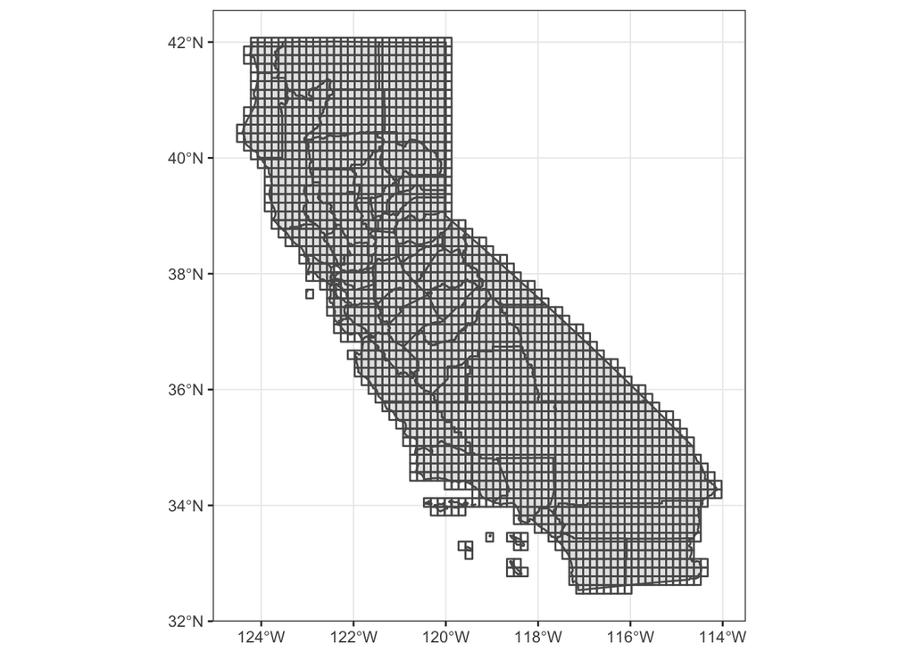

```r
# plot
ggplot(cali_county) +
  geom_sf() +
  geom_sf(data=cali_grid, aes(), alpha = 0.0) +
  theme_bw()
```

Next steps would be to figure out how to use the sf package with apply or map type functions.

```r
# define intersect function to output a vector
prop_int_fun <- function(x){
  county <- x
  # extract fips number for variable name
  fips_id <- paste0("fips_", county$FIPS)
  # subset grid cells that touch any part of the county
  grid <- cali_grid[county,]
  # output grid IDs
  grid_id <- grid$id
  # subset the intersected polygon
  inter_poly <- st_intersection(st_geometry(grid),st_geometry(county))
  # find proportion intersect with original grid
  prop_int <- as.numeric(st_area(inter_poly)/st_area(grid))
}

# test of la county
la_test <- prop_int_fun(la_county)

y <- cali_county %>%
  group_by(FIPS) %>%
  nest



test1 <- lapply(1:nrow(cali_county), prop_int_fun)


test <- sapply(x$geometry, prop_int_fun)


test3 <- cali_county %>%
  group_by(FIPS) %>%
  lmap(prop_int_fun)

test_apply <- lapply(cali_county, prop_int_fun)
```